# Model Extension Report

Leonardo Feitosa

17 March 2022

# Introduction

Invasive species management requires thorough understanding of life history characteristics, which can be used to model population dynamics and analyze effectiveness of various intervention strategies. Lionfish (*Pterois volitans/miles*) are an invasive species in the Caribbean, and have caused substantial harm to both the regional biological community and the people who rely on coral reefs for economic subsistence (Albins, 2015; Albins & Hixon, 2013). Since individual growth rates are often dependent on local environmental conditions, spatially-explicit estimates are necessary to better understand and manage lionfish invasions. Growth curves for this species have been generated for many locations throughout the Caribbean Sea (Akins et al., 2014; Rodríguez-Cortés, 2015). The paper we analyze in this project, by Eric G. Johnson and Mary Katherine Swenarton (2016), fills the knowledge gap on the individual-level growth patterns in a temperate population in Northeastern Florida.

Growth studies are also critical to understand how predator-prey interactions might be influenced by a rapid-growth invasive species such as the lionfish (Lorenzen, 2006). Johnson and Swenarton (2016) study the growth patterns and evaluate the population structure of *Pterois volitans/miles* through length-frequency data, applying a modified version of the von Bertalanffy Growth Function (VBGF) to include seasonality as an environmental parameter. In this paper, we recreate some of the analyses they performed in their paper and discuss the ecological importance of their results.

# Model Presentation

The von Bertalanffy growth function uses length as a proxy for age. Generally, the length of a fish increases as it gets older, and many fish species demonstrate rapid growth as juveniles that then decreases as they near their maximum size. For species which experience seasonal temperature variations, such as temperate lionfish, the seasonalized version of this length-age function is often most appropriate:

$$\begin{align}
\text{Seasonalized:}
\newline
L_t & = L_\infty [1-e^{-(K(t-t_0))-S(t)+S(t_0)}] \\
\newline
S(t) &= \frac{CK}{2\pi} \cdot sin \pi(t-t_s)
\newline
S(t_0) &= \frac{CK}{2\pi} \cdot sin \pi(t_0-t_s)
\end{align}$$

Here, the length of a fish at a certain age ($L_t$) is a function of the Brody growth coefficient ($K$) and fluctuations in the growth rate depending on the seasonal growth patterns (described by $S(t)$ and $S(t_0)$). The intensity of these fluctuations is controlled by $C$, where $C = 0$ indicates no seasonality, and $C = 1$ indicates complete seasonality. A complete list of parameters and their descriptions are included in Table 1.

## Model Extension’s Key Goals & Findings:

The paper analyzed in this project (Johnson & Swenarton 2016) consists of the calculations of growth for the lionfish (Pterois volitans/miles) in Northeastern Florida. While growth curves for this species have been generated throughout the region independently (Akins et al., 2014; Rodríguez-Cortés, 2015), the paper we analyzed does it in a very local scale within a limited time frame (2013-2015). Therefore, my proposal for an extension of this model is to include sea water temperature as another parameter, given that water temperature is key to the development and reproductive parameters of fish (Rountrey et al., 2014). Furthermore, given the recent extension records of the invasive lionfish beyond the Caribbean and as far south as Rio de Janeiro, southeastern Brazil (Ferreira et al., 2015; Luiz et al., 2021), the populations of this species are likely to be subjected to different sea water temperatures, thus likely exhibiting different growth patterns.

*Table 1. Description of variables and parameters for the seasonalized von-Bertalanffy growth equation with the addition of mean water temperature (T)*

| Term | Estimate | Description |
| --- | --- | --- |
| $L_t$ | output variable (mm) | length of fish at age $t$ |
| $t$ | input variable (yr) | age $t$ |
| $L_\infty$ | 448 mm | asymptotic maximum length |
| $K$ | 0.47 yr$^{-1}$ | Brody growth coefficient |
| $t_0$ | 0 yr | theoretical time at which fish was length zero artificial constant set at zero for this paper) |
| $t_s$ | 0.71 yr | seasonal growth oscillation relative to $t_0$ |
| $t_w$ | not stated | winter point, time of slowest growth ($t_w = t_s + 0.5$) |
| $t_b$ | 0.41 yr | time of annual recruitment |
| $C$ | 0.61 | intensity of seasonal growth oscillation ($0 \leq C \leq 1$, where zero indicates no seasonality and one indicates complete seasonality) |
| $T$ | 22.5(Fl), 23 (BRJ), 24 (BFN), 25 (BNB) | water temperature (ºC). FL - Florda, BRJ - Rio de Janeiro, BFN - Fernando de Noronha Archipelago, BNB - Northern Brazilian coast |

The authors used a maximum likelihood approach to fit a predicted distribution to the length-frequency histograms from samples of collected lionfish. Length is a proxy for age, so the model estimates the proportion of fish of a given size in each age class. In the Johnson & Swenarton (2016) paper, this function was used to estimate the parameters for the best fit model shown below.

$$\begin{align}
L_t = 448 [1-e^{-0.47t+[\frac{0.061*0.47}{2\pi}]sin\pi(t-0.71)]-[\frac{0.61*0.47}{2\pi}sin\pi(0.71)]}]
\end{align}$$

This model assumes the following:

- All individuals are identical and experience the same environmental conditions
- Individual growth is only controlled by the passage of time and predicted seasonal oscillations (e.g. not affected by changes in conditions, predator presence, prey availability)
- The distribution of lengths in the population follows a normal distribution
- The population of lionfish has only four age classes
- Lionfish in this population reach an average maximum length of 448 mm
- The samples collected via spearfishing are reflective of the age-length distribution of the population
- Recruitment occurs in a single event on the same day each year

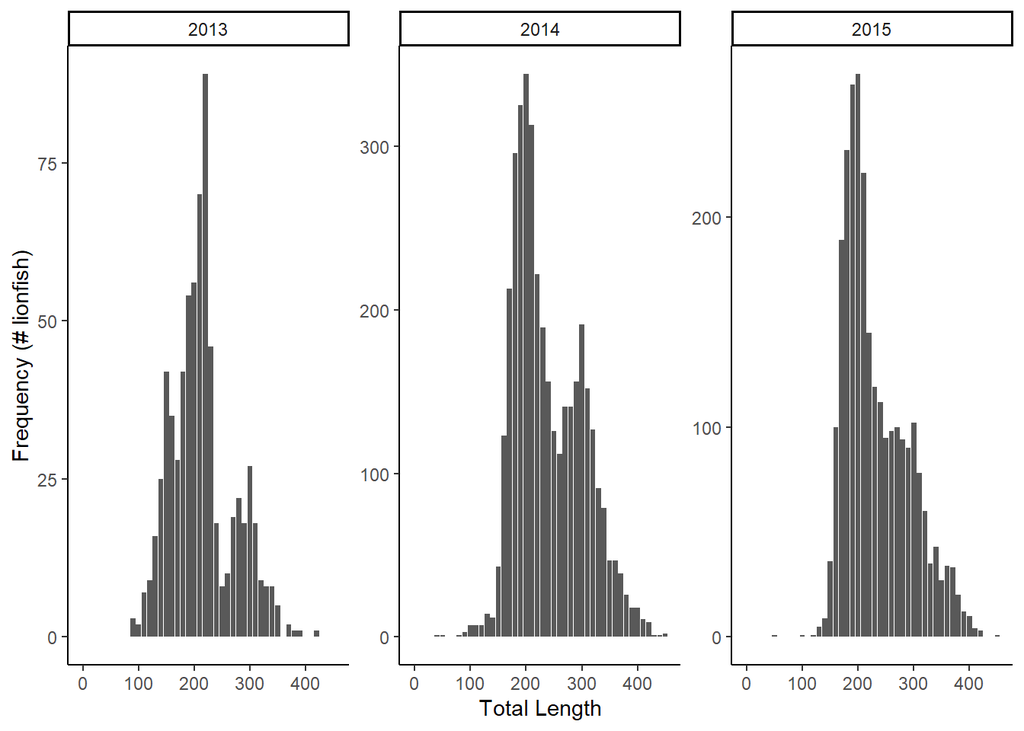

## Model extension results

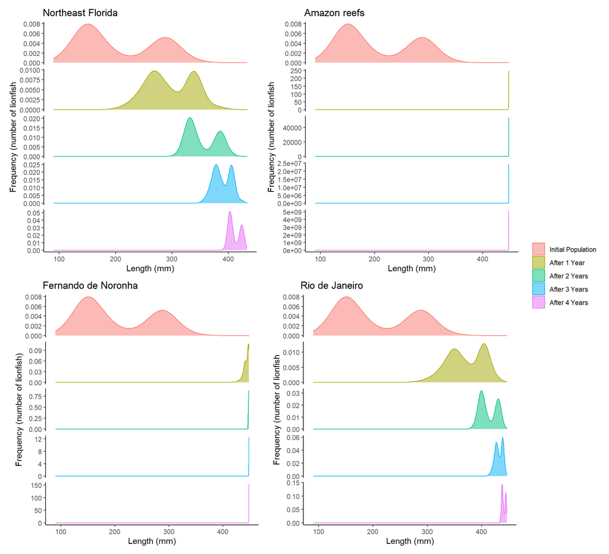

**Figure 2.** Shifting age and size structure of lionfish population, as sampled in April 2013 in Northeast Florida. This figure demonstrates growth of a single snapshot of individuals over four years, and does not account for any births, deaths, immigration, or emigration.

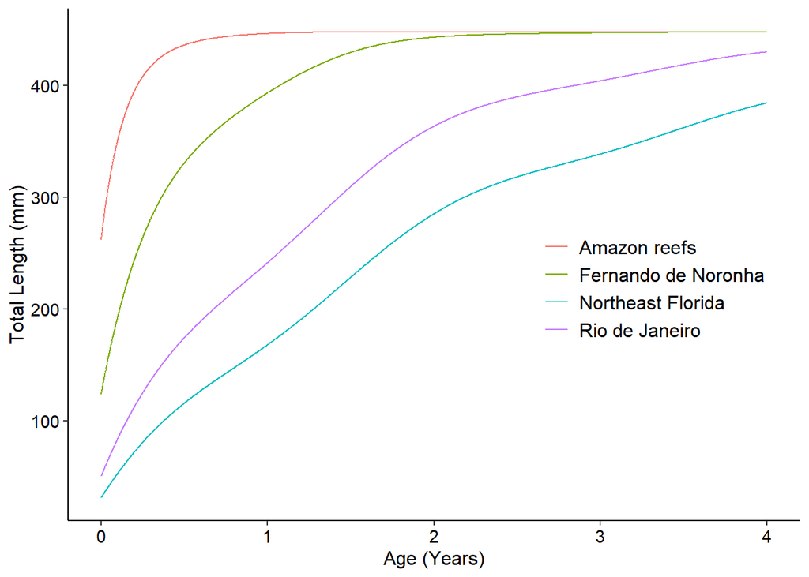

**Figure 3.** Estimated age-length relationship for lionfish in the modified version of the seasonalized von-Bertalanffy growth equation for each region.

# Ecological implications of this model extension

As shown in figures 2 and 3, by including average water temperature as a parameter for each different area this model extension estimates that lionfish individuals are more likely to show a skewed frequency towards higher sizes more quickly (Figure 2). This is because living in environments with higher temperatures than the ones found in Northeast Florida can cause fish to grow at a faster rate. This is clearly shown in Figure 3. However, it is necessary to state that these growth patterns are applied from the population of lionfish sampled in Northeast Florida on April 2013, and thus conclusions for other areas are likely to be somewhat different due to inherent baseline data differences.